# task 11

Darius Bušniauskas

Pakete datasets yra duomenų masyvas longley. Iš šio kintamųjų padarykite tiesinę regresiją, kur prognozuojamas kintamasis būtų GNP, o regresosius Employed. Jums reikia:

Padarykite modelio prognozes taškuose $62, 65, 68$.

Išbrėžkite kintamųjų sklaidos diagramą kartu su tiesinės regresijos tiese ir naujomis prognozėmis. Grafiką pateikite su pilna legena, kurioje būtų nurodyti visi žymėjimai.

**Įvertinti paprastosios tiesinės regresijos modelį. Pateikti modelio summary ir pakomentuoti ką reiškia gauti skaičiai. Kaip interpretuoti gautus rezultatus?**

```r
longley  #perziurim duomenu pasyva longley
```

```
##      GNP.deflator     GNP Unemployed Armed.Forces Population Year Employed
## 1947         83.0 234.289      235.6        159.0    107.608 1947   60.323
## 1948         88.5 259.426      232.5        145.6    108.632 1948   61.122
## 1949         88.2 258.054      368.2        161.6    109.773 1949   60.171
## 1950         89.5 284.599      335.1        165.0    110.929 1950   61.187
## 1951         96.2 328.975      209.9        309.9    112.075 1951   63.221
## 1952         98.1 346.999      193.2        359.4    113.270 1952   63.639
## 1953         99.0 365.385      187.0        354.7    115.094 1953   64.989
## 1954        100.0 363.112      357.8        335.0    116.219 1954   63.761
## 1955        101.2 397.469      290.4        304.8    117.388 1955   66.019
## 1956        104.6 419.180      282.2        285.7    118.734 1956   67.857
## 1957        108.4 442.769      293.6        279.8    120.445 1957   68.169
## 1958        110.8 444.546      468.1        263.7    121.950 1958   66.513
## 1959        112.6 482.704      381.3        255.2    123.366 1959   68.655
## 1960        114.2 502.601      393.1        251.4    125.368 1960   69.564
## 1961        115.7 518.173      480.6        257.2    127.852 1961   69.331
## 1962        116.9 554.894      400.7        282.7    130.081 1962   70.551
```

```r
x<-longley$Employed  #x priskiriam longlvey masyvo emplyoed reiksmes
y<-longley$GNP  #y prisikiriam longley masyvo GNP reiksmes
reg<- lm(y~x)  # padarom tiesines regresijos modeli is employed and GNP reiksmiu
summary(reg)
```

```
##
## Call:
## lm(formula = y ~ x)
##
## Residuals:
##     Min      1Q  Median      3Q     Max
## -39.223 -11.920   0.855  14.882  23.555
##
## Coefficients:
##              Estimate Std. Error t value Pr(>|t|)
## (Intercept) -1430.482     89.361  -16.01 2.15e-10 ***
## x              27.836      1.366   20.37 8.36e-12 ***
## ---
## Signif. codes:  0 '***' 0.001 '**' 0.01 '*' 0.05 '.' 0.1 ' ' 1
##
## Residual standard error: 18.58 on 14 degrees of freedom
## Multiple R-squared:  0.9674, Adjusted R-squared:  0.965
## F-statistic: 415.1 on 1 and 14 DF,  p-value: 8.363e-12
```

**Residuals** parodo paklaidą, nukrypimą kiek prognozuojami duomenys gali skirtis nuo stebimų duomenų, ir kaip jie pasiskirsto aplink isbrezta musu regresijos tiese. Šioje skiltyje yra 5 reikšmės **Min ir Max** rodo mažiausia ir didžiausia reiškmes, **1Q ir 3Q** tai yra kvartiliai, o **Median** tai vidurine duomenu variacinės eilutės reikšmė.

**Residual standard error** rodo paklaida tarp duomenu su tam tikru laisvės laipsniu.

**Multiple R-squared** tai skaicius parodantis kiek tinkamas yra modelis, ir kuo jis yra artesnis link 1 tuo modelis tinkamesnis.

**Padarykite modelio prognozes taškuose $62, 65, 68$.**

```r
x1=c(62, 65, 68)  # surasom i vektoriu tris taskus
y1 = predict(reg, data.frame(x=x1)) # prognozuojam 3 tasku progranozes pagal modeli
y1
```

```
##        1        2        3
## 295.3656 378.8743 462.3831
```

**Išbrėžkite kintamųjų sklaidos diagramą kartu su tiesinės regresijos tiese ir naujomis prognozėmis. Grafiką pateikite su pilna legena, kurioje būtų nurodyti visi žymėjimai.**

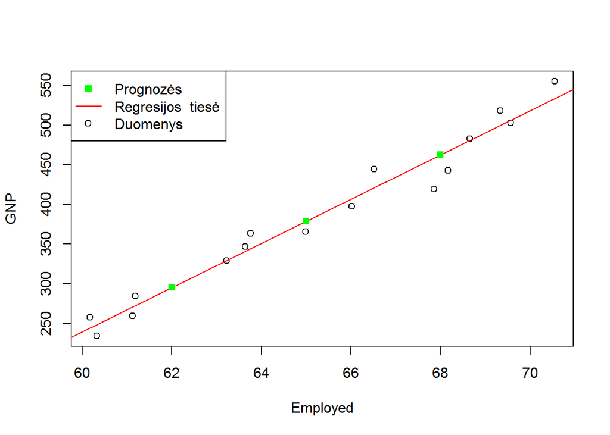

```r
plot(x,y, xlab='Employed', ylab='GNP')
abline(reg, col="red")
points(x1,y1, col="green", pch=15)
legend("topleft", c("Prognozės","Regresijos  tiesė", "Duomenys"), lty=c(0,1,0), pch=c(15,NA,1), col=c("green","red",1))
```

**Šaltiniai**: Editos Basytės darbas